# Project 2 - Tushar Chopra

# Part 1.1: Finite Differce Operator

[figure not shown]

# Part 1.2: Derivative of Gaussian (DoG) Filter

The differences are that there is less noise (randoom white dots in the image), which results in the edges of the main subjects of the photo to be more distinct

[figure not shown]

[figure not shown]

# Part 1.3: Image Straightening

### Here is the example image straightened

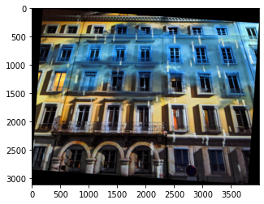

### Here are the histograms of veritcal and horizontal edges in the picture¶

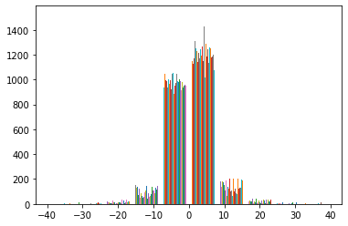

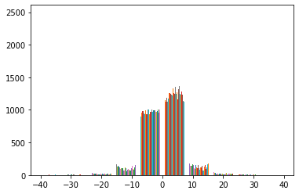

### Here is a failure case and the resulting histograms

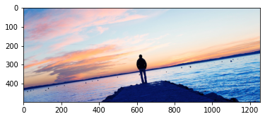

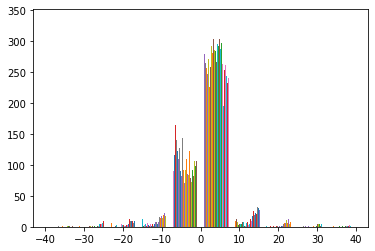

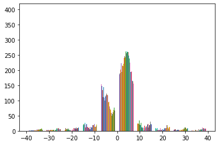

### Here are other pictures where it worked well

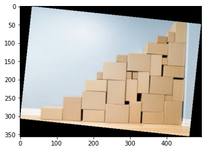

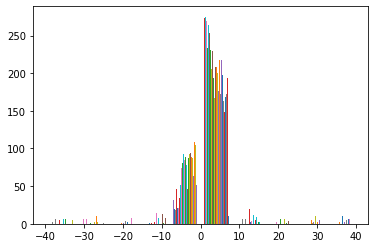

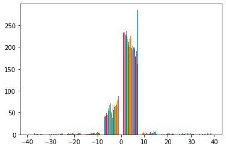

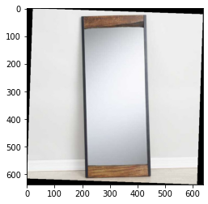

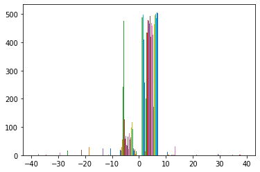

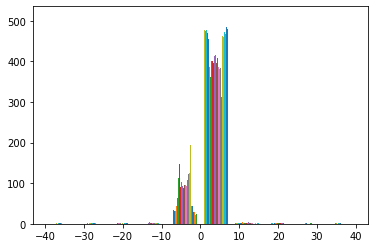

# Part 2.1: Image "Sharpening"

### I could not figure out why I was getting the results I am, even after consulting with other students. I create the blurred color image, subtract it from the original image to get the high pass filter, and add it back to the original image to create the sharpenned image. At least in theory....

```
Clipping input data to the valid range for imshow with RGB data ([0..1] for floats or [0..255] for integers).
```

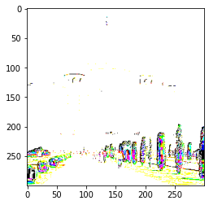

[figure not shown]

# Part 2.2: Hybrid Images

### Example images and result

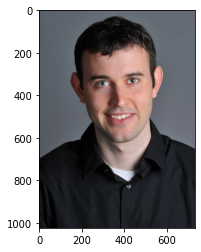

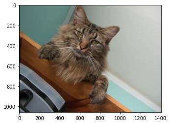

```
Clipping input data to the valid range for imshow with RGB data ([0..1] for floats or [0..255] for integers).
```

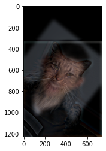

### I'd say these images, showing mood change, does not work as well, since the change is so subtle

```
Please select 2 points in each image for alignment.
```

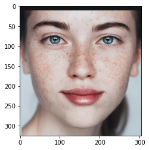

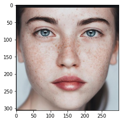

```
Clipping input data to the valid range for imshow with RGB data ([0..1] for floats or [0..255] for integers).
```

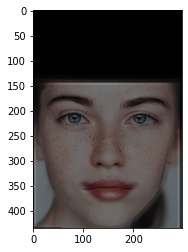

### This resulting hybrid image shows the Stanford tower close up and the Berkeley Campanile far away

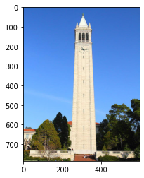

[figure not shown]

```
Clipping input data to the valid range for imshow with RGB data ([0..1] for floats or [0..255] for integers).
```

[figure not shown]

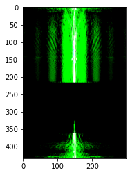

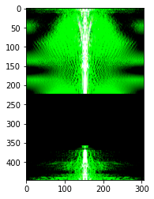

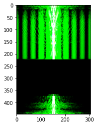

# Bells and Whistles

### I added color to the hybrid images by simply splitting the color channels when blurring and stacking them back together, and proceeding with the grayscale formula. I think color distracts from the hybrid as the inconstencies in color results in the viewer focusing on that instead of the hybrid edges.